# Risk Factor Analysis

## Outcome Variable

**Outcome Variable:** sstunted

## Predictor Variables

**Intervention Variable:** meducyrs

**Adjustment Set:**

unadjusted

## Stratifying Variables

The analysis was stratified on these variable(s):

- agecat
- studyid
- country

## Data Summary

| agecat | studyid | country | meducyrs | sstunted | n_cell | n |
| --- | --- | --- | --- | --- | --- | --- |
| Birth | ki0047075b-MAL-ED | BANGLADESH | Low | 0 | 65 | 207 |
| Birth | ki0047075b-MAL-ED | BANGLADESH | Low | 1 | 3 | 207 |
| Birth | ki0047075b-MAL-ED | BANGLADESH | Medium | 0 | 62 | 207 |
| Birth | ki0047075b-MAL-ED | BANGLADESH | Medium | 1 | 2 | 207 |
| Birth | ki0047075b-MAL-ED | BANGLADESH | High | 0 | 73 | 207 |
| Birth | ki0047075b-MAL-ED | BANGLADESH | High | 1 | 2 | 207 |
| Birth | ki0047075b-MAL-ED | BRAZIL | Low | 0 | 51 | 190 |
| Birth | ki0047075b-MAL-ED | BRAZIL | Low | 1 | 1 | 190 |
| Birth | ki0047075b-MAL-ED | BRAZIL | Medium | 0 | 69 | 190 |
| Birth | ki0047075b-MAL-ED | BRAZIL | Medium | 1 | 4 | 190 |
| Birth | ki0047075b-MAL-ED | BRAZIL | High | 0 | 62 | 190 |
| Birth | ki0047075b-MAL-ED | BRAZIL | High | 1 | 3 | 190 |
| Birth | ki0047075b-MAL-ED | INDIA | Low | 0 | 60 | 183 |
| Birth | ki0047075b-MAL-ED | INDIA | Low | 1 | 1 | 183 |
| Birth | ki0047075b-MAL-ED | INDIA | Medium | 0 | 69 | 183 |
| Birth | ki0047075b-MAL-ED | INDIA | Medium | 1 | 2 | 183 |
| Birth | ki0047075b-MAL-ED | INDIA | High | 0 | 49 | 183 |
| Birth | ki0047075b-MAL-ED | INDIA | High | 1 | 2 | 183 |
| Birth | ki0047075b-MAL-ED | NEPAL | Low | 0 | 65 | 160 |
| Birth | ki0047075b-MAL-ED | NEPAL | Low | 1 | 3 | 160 |
| Birth | ki0047075b-MAL-ED | NEPAL | Medium | 0 | 52 | 160 |
| Birth | ki0047075b-MAL-ED | NEPAL | Medium | 1 | 3 | 160 |
| Birth | ki0047075b-MAL-ED | NEPAL | High | 0 | 37 | 160 |
| Birth | ki0047075b-MAL-ED | NEPAL | High | 1 | 0 | 160 |
| Birth | ki0047075b-MAL-ED | PERU | Low | 0 | 98 | 286 |
| Birth | ki0047075b-MAL-ED | PERU | Low | 1 | 1 | 286 |
| Birth | ki0047075b-MAL-ED | PERU | Medium | 0 | 97 | 286 |
| Birth | ki0047075b-MAL-ED | PERU | Medium | 1 | 3 | 286 |
| Birth | ki0047075b-MAL-ED | PERU | High | 0 | 83 | 286 |
| Birth | ki0047075b-MAL-ED | PERU | High | 1 | 4 | 286 |

[output cut: 378 more lines]

The following strata were considered:

- agecat: 24 months, studyid: ki0047075b-MAL-ED, country: BANGLADESH
- agecat: 24 months, studyid: ki0047075b-MAL-ED, country: BRAZIL
- agecat: 24 months, studyid: ki0047075b-MAL-ED, country: INDIA
- agecat: 24 months, studyid: ki0047075b-MAL-ED, country: NEPAL
- agecat: 24 months, studyid: ki0047075b-MAL-ED, country: PERU
- agecat: 24 months, studyid: ki0047075b-MAL-ED, country: SOUTH AFRICA
- agecat: 24 months, studyid: ki0047075b-MAL-ED, country: TANZANIA, UNITED REPUBLIC OF
- agecat: 24 months, studyid: ki1000108-CMC-V-BCS-2002, country: INDIA
- agecat: 24 months, studyid: ki1000108-IRC, country: INDIA
- agecat: 24 months, studyid: ki1017093-NIH-Birth, country: BANGLADESH
- agecat: 24 months, studyid: ki1017093b-PROVIDE, country: BANGLADESH
- agecat: 24 months, studyid: ki1017093c-NIH-Crypto, country: BANGLADESH
- agecat: 24 months, studyid: ki1066203-TanzaniaChild2, country: TANZANIA, UNITED REPUBLIC OF
- agecat: 24 months, studyid: ki1113344-GMS-Nepal, country: NEPAL
- agecat: 24 months, studyid: ki1119695-PROBIT, country: BELARUS
- agecat: 24 months, studyid: ki1126311-ZVITAMBO, country: ZIMBABWE
- agecat: 24 months, studyid: ki1135781-COHORTS, country: GUATEMALA
- agecat: 24 months, studyid: ki1135781-COHORTS, country: INDIA
- agecat: 24 months, studyid: ki1135781-COHORTS, country: PHILIPPINES
- agecat: 24 months, studyid: ki1148112-LCNI-5, country: MALAWI
- agecat: 24 months, studyid: kiGH5241-JiVitA-3, country: BANGLADESH
- agecat: 24 months, studyid: kiGH5241-JiVitA-4, country: BANGLADESH
- agecat: 6 months, studyid: ki0047075b-MAL-ED, country: BANGLADESH
- agecat: 6 months, studyid: ki0047075b-MAL-ED, country: BRAZIL
- agecat: 6 months, studyid: ki0047075b-MAL-ED, country: INDIA
- agecat: 6 months, studyid: ki0047075b-MAL-ED, country: NEPAL
- agecat: 6 months, studyid: ki0047075b-MAL-ED, country: PERU
- agecat: 6 months, studyid: ki0047075b-MAL-ED, country: SOUTH AFRICA
- agecat: 6 months, studyid: ki0047075b-MAL-ED, country: TANZANIA, UNITED REPUBLIC OF
- agecat: 6 months, studyid: ki1000108-CMC-V-BCS-2002, country: INDIA
- agecat: 6 months, studyid: ki1000108-IRC, country: INDIA
- agecat: 6 months, studyid: ki1000109-EE, country: PAKISTAN
- agecat: 6 months, studyid: ki1000304b-SAS-CompFeed, country: INDIA
- agecat: 6 months, studyid: ki1000304b-SAS-FoodSuppl, country: INDIA
- agecat: 6 months, studyid: ki1017093-NIH-Birth, country: BANGLADESH
- agecat: 6 months, studyid: ki1017093b-PROVIDE, country: BANGLADESH
- agecat: 6 months, studyid: ki1017093c-NIH-Crypto, country: BANGLADESH
- agecat: 6 months, studyid: ki1066203-TanzaniaChild2, country: TANZANIA, UNITED REPUBLIC OF
- agecat: 6 months, studyid: ki1112895-Guatemala BSC, country: GUATEMALA
- agecat: 6 months, studyid: ki1113344-GMS-Nepal, country: NEPAL
- agecat: 6 months, studyid: ki1119695-PROBIT, country: BELARUS
- agecat: 6 months, studyid: ki1126311-ZVITAMBO, country: ZIMBABWE
- agecat: 6 months, studyid: ki1135781-COHORTS, country: GUATEMALA
- agecat: 6 months, studyid: ki1135781-COHORTS, country: INDIA
- agecat: 6 months, studyid: ki1135781-COHORTS, country: PHILIPPINES
- agecat: 6 months, studyid: ki1148112-LCNI-5, country: MALAWI
- agecat: 6 months, studyid: kiGH5241-JiVitA-3, country: BANGLADESH
- agecat: 6 months, studyid: kiGH5241-JiVitA-4, country: BANGLADESH
- agecat: Birth, studyid: ki0047075b-MAL-ED, country: BANGLADESH
- agecat: Birth, studyid: ki0047075b-MAL-ED, country: BRAZIL
- agecat: Birth, studyid: ki0047075b-MAL-ED, country: INDIA
- agecat: Birth, studyid: ki0047075b-MAL-ED, country: NEPAL
- agecat: Birth, studyid: ki0047075b-MAL-ED, country: PERU
- agecat: Birth, studyid: ki0047075b-MAL-ED, country: SOUTH AFRICA
- agecat: Birth, studyid: ki0047075b-MAL-ED, country: TANZANIA, UNITED REPUBLIC OF
- agecat: Birth, studyid: ki1000108-CMC-V-BCS-2002, country: INDIA
- agecat: Birth, studyid: ki1000108-IRC, country: INDIA
- agecat: Birth, studyid: ki1000109-EE, country: PAKISTAN
- agecat: Birth, studyid: ki1000304b-SAS-CompFeed, country: INDIA
- agecat: Birth, studyid: ki1017093-NIH-Birth, country: BANGLADESH
- agecat: Birth, studyid: ki1017093c-NIH-Crypto, country: BANGLADESH
- agecat: Birth, studyid: ki1119695-PROBIT, country: BELARUS
- agecat: Birth, studyid: ki1126311-ZVITAMBO, country: ZIMBABWE
- agecat: Birth, studyid: ki1135781-COHORTS, country: GUATEMALA
- agecat: Birth, studyid: ki1135781-COHORTS, country: INDIA
- agecat: Birth, studyid: ki1135781-COHORTS, country: PHILIPPINES
- agecat: Birth, studyid: kiGH5241-JiVitA-3, country: BANGLADESH
- agecat: Birth, studyid: kiGH5241-JiVitA-4, country: BANGLADESH

### Dropped Strata

Some strata were dropped due to rare outcomes:

- agecat: Birth, studyid: ki0047075b-MAL-ED, country: BANGLADESH
- agecat: Birth, studyid: ki0047075b-MAL-ED, country: BRAZIL
- agecat: Birth, studyid: ki0047075b-MAL-ED, country: INDIA
- agecat: Birth, studyid: ki0047075b-MAL-ED, country: NEPAL
- agecat: Birth, studyid: ki0047075b-MAL-ED, country: PERU
- agecat: Birth, studyid: ki0047075b-MAL-ED, country: SOUTH AFRICA
- agecat: Birth, studyid: ki0047075b-MAL-ED, country: TANZANIA, UNITED REPUBLIC OF
- agecat: Birth, studyid: ki1000108-CMC-V-BCS-2002, country: INDIA
- agecat: Birth, studyid: ki1000108-IRC, country: INDIA
- agecat: Birth, studyid: ki1000109-EE, country: PAKISTAN
- agecat: Birth, studyid: ki1000304b-SAS-CompFeed, country: INDIA
- agecat: Birth, studyid: ki1017093-NIH-Birth, country: BANGLADESH
- agecat: Birth, studyid: ki1017093c-NIH-Crypto, country: BANGLADESH
- agecat: Birth, studyid: ki1119695-PROBIT, country: BELARUS
- agecat: Birth, studyid: ki1135781-COHORTS, country: GUATEMALA
- agecat: Birth, studyid: kiGH5241-JiVitA-4, country: BANGLADESH
- agecat: 6 months, studyid: ki0047075b-MAL-ED, country: BANGLADESH
- agecat: 6 months, studyid: ki0047075b-MAL-ED, country: BRAZIL
- agecat: 6 months, studyid: ki0047075b-MAL-ED, country: INDIA
- agecat: 6 months, studyid: ki0047075b-MAL-ED, country: NEPAL
- agecat: 6 months, studyid: ki0047075b-MAL-ED, country: PERU
- agecat: 6 months, studyid: ki0047075b-MAL-ED, country: SOUTH AFRICA
- agecat: 6 months, studyid: ki0047075b-MAL-ED, country: TANZANIA, UNITED REPUBLIC OF
- agecat: 6 months, studyid: ki1000109-EE, country: PAKISTAN
- agecat: 6 months, studyid: ki1000304b-SAS-FoodSuppl, country: INDIA
- agecat: 6 months, studyid: ki1017093-NIH-Birth, country: BANGLADESH
- agecat: 6 months, studyid: ki1017093b-PROVIDE, country: BANGLADESH
- agecat: 6 months, studyid: ki1066203-TanzaniaChild2, country: TANZANIA, UNITED REPUBLIC OF
- agecat: 6 months, studyid: ki1113344-GMS-Nepal, country: NEPAL
- agecat: 24 months, studyid: ki0047075b-MAL-ED, country: BANGLADESH
- agecat: 24 months, studyid: ki0047075b-MAL-ED, country: BRAZIL
- agecat: 24 months, studyid: ki0047075b-MAL-ED, country: INDIA
- agecat: 24 months, studyid: ki0047075b-MAL-ED, country: NEPAL
- agecat: 24 months, studyid: ki0047075b-MAL-ED, country: PERU
- agecat: 24 months, studyid: ki0047075b-MAL-ED, country: SOUTH AFRICA
- agecat: 24 months, studyid: ki0047075b-MAL-ED, country: TANZANIA, UNITED REPUBLIC OF
- agecat: 24 months, studyid: ki1066203-TanzaniaChild2, country: TANZANIA, UNITED REPUBLIC OF
- agecat: 24 months, studyid: ki1113344-GMS-Nepal, country: NEPAL
- agecat: 24 months, studyid: ki1119695-PROBIT, country: BELARUS

## Methods Detail

We’re interested in the causal parameters $E[Y_a]$ for all values of $a \in \mathcal{A}$. These parameters represent the mean outcome if, possibly contrary to fact, we intervened to set all units to have $A=a$. Under the randomization and positivity assumptions, these are identified by the statistical parameters $\psi_a=E_W[E_{Y|A,W}(Y|A=a,W)]$. In addition, we’re interested in the mean of $Y$, $E[Y]$ under no intervention (the observed mean). We will estimate these parameters by using SuperLearner to fit the relevant likelihood factors – $E_{Y|A,W}(Y|A=a,W)$ and $p(A=a|W)$, and then updating our likelihood fit using a joint TMLE.

For unadjusted analyses ($W=\{\}$), initial likelihoods were estimated using Lrnr_glm to estimate the simple $E(Y|A)$ and Lrnr_mean to estimate $p(A)$. For adjusted analyses, a small library containing Lrnr_glmnet, Lrnr_xgboost, and Lrnr_mean was used.

Having estimated these parameters, we will then use the delta method to estimate relative risks and attributable risks relative to a prespecified baseline level of $A$.

# Results Detail

## Results Plots

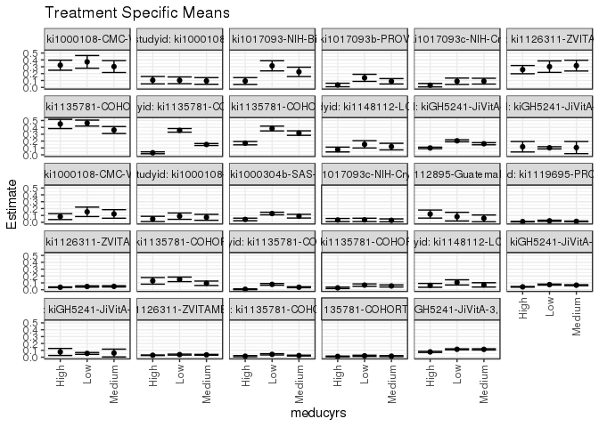

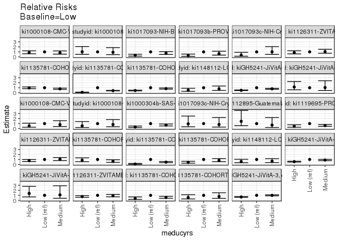

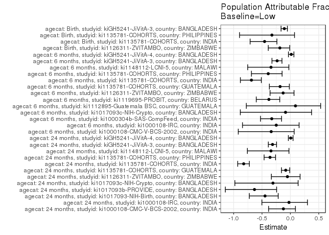

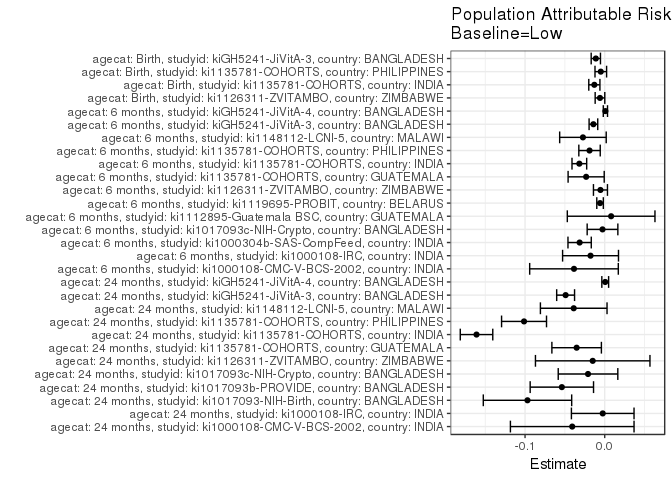

## Results Table

### Parameter: TSM

| agecat | studyid | country | intervention_level | baseline_level | estimate | ci_lower | ci_upper |
| --- | --- | --- | --- | --- | --- | --- | --- |
| Birth | ki1126311-ZVITAMBO | ZIMBABWE | Low | NA | 0.0378788 | 0.0309353 | 0.0448223 |
| Birth | ki1126311-ZVITAMBO | ZIMBABWE | Medium | NA | 0.0345130 | 0.0283940 | 0.0406320 |
| Birth | ki1126311-ZVITAMBO | ZIMBABWE | High | NA | 0.0284493 | 0.0246833 | 0.0322153 |
| Birth | ki1135781-COHORTS | INDIA | Low | NA | 0.0415718 | 0.0322348 | 0.0509087 |
| Birth | ki1135781-COHORTS | INDIA | Medium | NA | 0.0237239 | 0.0180682 | 0.0293797 |
| Birth | ki1135781-COHORTS | INDIA | High | NA | 0.0147493 | 0.0056745 | 0.0238240 |
| Birth | ki1135781-COHORTS | PHILIPPINES | Low | NA | 0.0200000 | 0.0108520 | 0.0291480 |
| Birth | ki1135781-COHORTS | PHILIPPINES | Medium | NA | 0.0152905 | 0.0076107 | 0.0229703 |
| Birth | ki1135781-COHORTS | PHILIPPINES | High | NA | 0.0111206 | 0.0051082 | 0.0171330 |
| Birth | kiGH5241-JiVitA-3 | BANGLADESH | Low | NA | 0.1153603 | 0.1081551 | 0.1225655 |
| Birth | kiGH5241-JiVitA-3 | BANGLADESH | Medium | NA | 0.1142066 | 0.1053869 | 0.1230262 |
| Birth | kiGH5241-JiVitA-3 | BANGLADESH | High | NA | 0.0772695 | 0.0694186 | 0.0851203 |
| 6 months | ki1000108-CMC-V-BCS-2002 | INDIA | Low | NA | 0.1523810 | 0.0835461 | 0.2212158 |
| 6 months | ki1000108-CMC-V-BCS-2002 | INDIA | Medium | NA | 0.1214953 | 0.0595088 | 0.1834819 |
| 6 months | ki1000108-CMC-V-BCS-2002 | INDIA | High | NA | 0.0828025 | 0.0396366 | 0.1259684 |
| 6 months | ki1000108-IRC | INDIA | Low | NA | 0.0890411 | 0.0427870 | 0.1352952 |
| 6 months | ki1000108-IRC | INDIA | Medium | NA | 0.0724638 | 0.0291557 | 0.1157718 |
| 6 months | ki1000108-IRC | INDIA | High | NA | 0.0487805 | 0.0106657 | 0.0868952 |
| 6 months | ki1000304b-SAS-CompFeed | INDIA | Low | NA | 0.1273032 | 0.1083867 | 0.1462196 |
| 6 months | ki1000304b-SAS-CompFeed | INDIA | Medium | NA | 0.0890869 | 0.0621624 | 0.1160113 |
| 6 months | ki1000304b-SAS-CompFeed | INDIA | High | NA | 0.0413793 | 0.0226362 | 0.0601225 |
| 6 months | ki1017093c-NIH-Crypto | BANGLADESH | Low | NA | 0.0349345 | 0.0111365 | 0.0587325 |
| 6 months | ki1017093c-NIH-Crypto | BANGLADESH | Medium | NA | 0.0284553 | 0.0076632 | 0.0492473 |
| 6 months | ki1017093c-NIH-Crypto | BANGLADESH | High | NA | 0.0333333 | 0.0106073 | 0.0560594 |
| 6 months | ki1112895-Guatemala BSC | GUATEMALA | Low | NA | 0.0821918 | 0.0190725 | 0.1453111 |
| 6 months | ki1112895-Guatemala BSC | GUATEMALA | Medium | NA | 0.0574713 | 0.0084769 | 0.1064657 |
| 6 months | ki1112895-Guatemala BSC | GUATEMALA | High | NA | 0.1196581 | 0.0607416 | 0.1785747 |
| 6 months | ki1119695-PROBIT | BELARUS | Low | NA | 0.0212615 | 0.0126112 | 0.0299118 |
| 6 months | ki1119695-PROBIT | BELARUS | Medium | NA | 0.0130027 | 0.0079166 | 0.0180888 |
| 6 months | ki1119695-PROBIT | BELARUS | High | NA | 0.0097855 | 0.0061891 | 0.0133818 |

[output cut: 57 more lines]

### Parameter: E(Y)

| agecat | studyid | country | intervention_level | baseline_level | estimate | ci_lower | ci_upper |
| --- | --- | --- | --- | --- | --- | --- | --- |
| Birth | ki1126311-ZVITAMBO | ZIMBABWE | NA | NA | 0.0319334 | 0.0290009 | 0.0348659 |
| Birth | ki1135781-COHORTS | INDIA | NA | NA | 0.0285660 | 0.0240448 | 0.0330871 |
| Birth | ki1135781-COHORTS | PHILIPPINES | NA | NA | 0.0150820 | 0.0107558 | 0.0194081 |
| Birth | kiGH5241-JiVitA-3 | BANGLADESH | NA | NA | 0.1042018 | 0.0995258 | 0.1088777 |
| 6 months | ki1000108-CMC-V-BCS-2002 | INDIA | NA | NA | 0.1138211 | 0.0813725 | 0.1462698 |
| 6 months | ki1000108-IRC | INDIA | NA | NA | 0.0712531 | 0.0462303 | 0.0962759 |
| 6 months | ki1000304b-SAS-CompFeed | INDIA | NA | NA | 0.0958084 | 0.0774939 | 0.1141229 |
| 6 months | ki1017093c-NIH-Crypto | BANGLADESH | NA | NA | 0.0321678 | 0.0192256 | 0.0451101 |
| 6 months | ki1112895-Guatemala BSC | GUATEMALA | NA | NA | 0.0902527 | 0.0564475 | 0.1240580 |
| 6 months | ki1119695-PROBIT | BELARUS | NA | NA | 0.0154178 | 0.0100323 | 0.0208033 |
| 6 months | ki1126311-ZVITAMBO | ZIMBABWE | NA | NA | 0.0417773 | 0.0374680 | 0.0460867 |
| 6 months | ki1135781-COHORTS | GUATEMALA | NA | NA | 0.1281513 | 0.1069071 | 0.1493954 |
| 6 months | ki1135781-COHORTS | INDIA | NA | NA | 0.0463699 | 0.0407674 | 0.0519723 |
| 6 months | ki1135781-COHORTS | PHILIPPINES | NA | NA | 0.0487445 | 0.0406327 | 0.0568562 |
| 6 months | ki1148112-LCNI-5 | MALAWI | NA | NA | 0.0799508 | 0.0612962 | 0.0986054 |
| 6 months | kiGH5241-JiVitA-3 | BANGLADESH | NA | NA | 0.0606684 | 0.0568070 | 0.0645298 |
| 6 months | kiGH5241-JiVitA-4 | BANGLADESH | NA | NA | 0.0561826 | 0.0434820 | 0.0688832 |
| 24 months | ki1000108-CMC-V-BCS-2002 | INDIA | NA | NA | 0.3306452 | 0.2827744 | 0.3785159 |
| 24 months | ki1000108-IRC | INDIA | NA | NA | 0.1002445 | 0.0711031 | 0.1293859 |
| 24 months | ki1017093-NIH-Birth | BANGLADESH | NA | NA | 0.2167832 | 0.1777459 | 0.2558205 |
| 24 months | ki1017093b-PROVIDE | BANGLADESH | NA | NA | 0.0849220 | 0.0621566 | 0.1076874 |
| 24 months | ki1017093c-NIH-Crypto | BANGLADESH | NA | NA | 0.0680934 | 0.0462948 | 0.0898920 |
| 24 months | ki1126311-ZVITAMBO | ZIMBABWE | NA | NA | 0.2866521 | 0.2451477 | 0.3281565 |
| 24 months | ki1135781-COHORTS | GUATEMALA | NA | NA | 0.4273585 | 0.3975639 | 0.4571531 |
| 24 months | ki1135781-COHORTS | INDIA | NA | NA | 0.1954297 | 0.1834374 | 0.2074219 |
| 24 months | ki1135781-COHORTS | PHILIPPINES | NA | NA | 0.2817996 | 0.2639639 | 0.2996353 |
| 24 months | ki1148112-LCNI-5 | MALAWI | NA | NA | 0.1136364 | 0.0876051 | 0.1396676 |
| 24 months | kiGH5241-JiVitA-3 | BANGLADESH | NA | NA | 0.1556615 | 0.1469265 | 0.1643965 |
| 24 months | kiGH5241-JiVitA-4 | BANGLADESH | NA | NA | 0.1030612 | 0.0873670 | 0.1187554 |

### Parameter: RR

| agecat | studyid | country | intervention_level | baseline_level | estimate | ci_lower | ci_upper |
| --- | --- | --- | --- | --- | --- | --- | --- |
| Birth | ki1126311-ZVITAMBO | ZIMBABWE | Low | Low | 1.0000000 | 1.0000000 | 1.0000000 |
| Birth | ki1126311-ZVITAMBO | ZIMBABWE | Medium | Low | 0.9111436 | 0.7060458 | 1.1758199 |
| Birth | ki1126311-ZVITAMBO | ZIMBABWE | High | Low | 0.7510618 | 0.5990705 | 0.9416153 |
| Birth | ki1135781-COHORTS | INDIA | Low | Low | 1.0000000 | 1.0000000 | 1.0000000 |
| Birth | ki1135781-COHORTS | INDIA | Medium | Low | 0.5706745 | 0.4112843 | 0.7918353 |
| Birth | ki1135781-COHORTS | INDIA | High | Low | 0.3547906 | 0.1842971 | 0.6830079 |
| Birth | ki1135781-COHORTS | PHILIPPINES | Low | Low | 1.0000000 | 1.0000000 | 1.0000000 |
| Birth | ki1135781-COHORTS | PHILIPPINES | Medium | Low | 0.7645260 | 0.3875844 | 1.5080585 |
| Birth | ki1135781-COHORTS | PHILIPPINES | High | Low | 0.5560308 | 0.2738668 | 1.1289072 |
| Birth | kiGH5241-JiVitA-3 | BANGLADESH | Low | Low | 1.0000000 | 1.0000000 | 1.0000000 |
| Birth | kiGH5241-JiVitA-3 | BANGLADESH | Medium | Low | 0.9899993 | 0.8932621 | 1.0972128 |
| Birth | kiGH5241-JiVitA-3 | BANGLADESH | High | Low | 0.6698100 | 0.5952138 | 0.7537549 |
| 6 months | ki1000108-CMC-V-BCS-2002 | INDIA | Low | Low | 1.0000000 | 1.0000000 | 1.0000000 |
| 6 months | ki1000108-CMC-V-BCS-2002 | INDIA | Medium | Low | 0.7973131 | 0.4033514 | 1.5760655 |
| 6 months | ki1000108-CMC-V-BCS-2002 | INDIA | High | Low | 0.5433917 | 0.2726067 | 1.0831521 |
| 6 months | ki1000108-IRC | INDIA | Low | Low | 1.0000000 | 1.0000000 | 1.0000000 |
| 6 months | ki1000108-IRC | INDIA | Medium | Low | 0.8138239 | 0.3686650 | 1.7965071 |
| 6 months | ki1000108-IRC | INDIA | High | Low | 0.5478424 | 0.2143719 | 1.4000494 |
| 6 months | ki1000304b-SAS-CompFeed | INDIA | Low | Low | 1.0000000 | 1.0000000 | 1.0000000 |
| 6 months | ki1000304b-SAS-CompFeed | INDIA | Medium | Low | 0.6998007 | 0.5335849 | 0.9177940 |
| 6 months | ki1000304b-SAS-CompFeed | INDIA | High | Low | 0.3250454 | 0.2049137 | 0.5156049 |
| 6 months | ki1017093c-NIH-Crypto | BANGLADESH | Low | Low | 1.0000000 | 1.0000000 | 1.0000000 |
| 6 months | ki1017093c-NIH-Crypto | BANGLADESH | Medium | Low | 0.8145325 | 0.2999546 | 2.2118786 |
| 6 months | ki1017093c-NIH-Crypto | BANGLADESH | High | Low | 0.9541667 | 0.3639632 | 2.5014455 |
| 6 months | ki1112895-Guatemala BSC | GUATEMALA | Low | Low | 1.0000000 | 1.0000000 | 1.0000000 |
| 6 months | ki1112895-Guatemala BSC | GUATEMALA | Medium | Low | 0.6992337 | 0.2219811 | 2.2025649 |
| 6 months | ki1112895-Guatemala BSC | GUATEMALA | High | Low | 1.4558405 | 0.5846999 | 3.6248875 |
| 6 months | ki1119695-PROBIT | BELARUS | Low | Low | 1.0000000 | 1.0000000 | 1.0000000 |
| 6 months | ki1119695-PROBIT | BELARUS | Medium | Low | 0.6115594 | 0.4585554 | 0.8156156 |
| 6 months | ki1119695-PROBIT | BELARUS | High | Low | 0.4602434 | 0.2752333 | 0.7696161 |

[output cut: 57 more lines]

### Parameter: PAR

| agecat | studyid | country | intervention_level | baseline_level | estimate | ci_lower | ci_upper |
| --- | --- | --- | --- | --- | --- | --- | --- |
| Birth | ki1126311-ZVITAMBO | ZIMBABWE | Low | NA | -0.0059454 | -0.0119899 | 0.0000991 |
| Birth | ki1135781-COHORTS | INDIA | Low | NA | -0.0130058 | -0.0200002 | -0.0060114 |
| Birth | ki1135781-COHORTS | PHILIPPINES | Low | NA | -0.0049180 | -0.0121990 | 0.0023630 |
| Birth | kiGH5241-JiVitA-3 | BANGLADESH | Low | NA | -0.0111585 | -0.0169799 | -0.0053371 |
| 6 months | ki1000108-CMC-V-BCS-2002 | INDIA | Low | NA | -0.0385598 | -0.0941889 | 0.0170693 |
| 6 months | ki1000108-IRC | INDIA | Low | NA | -0.0177880 | -0.0528687 | 0.0172926 |
| 6 months | ki1000304b-SAS-CompFeed | INDIA | Low | NA | -0.0314948 | -0.0461215 | -0.0168681 |
| 6 months | ki1017093c-NIH-Crypto | BANGLADESH | Low | NA | -0.0027667 | -0.0220298 | 0.0164965 |
| 6 months | ki1112895-Guatemala BSC | GUATEMALA | Low | NA | 0.0080609 | -0.0469568 | 0.0630786 |
| 6 months | ki1119695-PROBIT | BELARUS | Low | NA | -0.0058437 | -0.0099558 | -0.0017316 |
| 6 months | ki1126311-ZVITAMBO | ZIMBABWE | Low | NA | -0.0053431 | -0.0141330 | 0.0034469 |
| 6 months | ki1135781-COHORTS | GUATEMALA | Low | NA | -0.0232964 | -0.0459624 | -0.0006304 |
| 6 months | ki1135781-COHORTS | INDIA | Low | NA | -0.0318519 | -0.0410675 | -0.0226362 |
| 6 months | ki1135781-COHORTS | PHILIPPINES | Low | NA | -0.0190521 | -0.0324857 | -0.0056186 |
| 6 months | ki1148112-LCNI-5 | MALAWI | Low | NA | -0.0273289 | -0.0565377 | 0.0018799 |
| 6 months | kiGH5241-JiVitA-3 | BANGLADESH | Low | NA | -0.0141870 | -0.0196108 | -0.0087632 |
| 6 months | kiGH5241-JiVitA-4 | BANGLADESH | Low | NA | 0.0008657 | -0.0017851 | 0.0035165 |
| 24 months | ki1000108-CMC-V-BCS-2002 | INDIA | Low | NA | -0.0407834 | -0.1183807 | 0.0368139 |
| 24 months | ki1000108-IRC | INDIA | Low | NA | -0.0024952 | -0.0417988 | 0.0368083 |
| 24 months | ki1017093-NIH-Birth | BANGLADESH | Low | NA | -0.0969423 | -0.1524168 | -0.0414678 |
| 24 months | ki1017093b-PROVIDE | BANGLADESH | Low | NA | -0.0538063 | -0.0935841 | -0.0140285 |
| 24 months | ki1017093c-NIH-Crypto | BANGLADESH | Low | NA | -0.0209477 | -0.0583475 | 0.0164521 |
| 24 months | ki1126311-ZVITAMBO | ZIMBABWE | Low | NA | -0.0150721 | -0.0869418 | 0.0567977 |
| 24 months | ki1135781-COHORTS | GUATEMALA | Low | NA | -0.0352399 | -0.0663177 | -0.0041622 |
| 24 months | ki1135781-COHORTS | INDIA | Low | NA | -0.1609283 | -0.1813246 | -0.1405320 |
| 24 months | ki1135781-COHORTS | PHILIPPINES | Low | NA | -0.1012649 | -0.1294768 | -0.0730530 |
| 24 months | ki1148112-LCNI-5 | MALAWI | Low | NA | -0.0389060 | -0.0807244 | 0.0029124 |
| 24 months | kiGH5241-JiVitA-3 | BANGLADESH | Low | NA | -0.0490734 | -0.0602967 | -0.0378502 |
| 24 months | kiGH5241-JiVitA-4 | BANGLADESH | Low | NA | 0.0006450 | -0.0036153 | 0.0049053 |

### Parameter: PAF

| agecat | studyid | country | intervention_level | baseline_level | estimate | ci_lower | ci_upper |
| --- | --- | --- | --- | --- | --- | --- | --- |
| Birth | ki1126311-ZVITAMBO | ZIMBABWE | Low | NA | -0.1861815 | -0.3905677 | -0.0118362 |
| Birth | ki1135781-COHORTS | INDIA | Low | NA | -0.4552904 | -0.7102745 | -0.2383217 |
| Birth | ki1135781-COHORTS | PHILIPPINES | Low | NA | -0.3260870 | -0.8958480 | 0.0724433 |
| Birth | kiGH5241-JiVitA-3 | BANGLADESH | Low | NA | -0.1070855 | -0.1649569 | -0.0520889 |
| 6 months | ki1000108-CMC-V-BCS-2002 | INDIA | Low | NA | -0.3387755 | -0.9195952 | 0.0663032 |
| 6 months | ki1000108-IRC | INDIA | Low | NA | -0.2496457 | -0.8436755 | 0.1529884 |
| 6 months | ki1000304b-SAS-CompFeed | INDIA | Low | NA | -0.3287270 | -0.5268821 | -0.1562879 |
| 6 months | ki1017093c-NIH-Crypto | BANGLADESH | Low | NA | -0.0860072 | -0.8833659 | 0.3737745 |
| 6 months | ki1112895-Guatemala BSC | GUATEMALA | Low | NA | 0.0893151 | -0.7771256 | 0.5333211 |
| 6 months | ki1119695-PROBIT | BELARUS | Low | NA | -0.3790237 | -0.6015492 | -0.1874168 |
| 6 months | ki1126311-ZVITAMBO | ZIMBABWE | Low | NA | -0.1278940 | -0.3587485 | 0.0637379 |
| 6 months | ki1135781-COHORTS | GUATEMALA | Low | NA | -0.1817883 | -0.3706245 | -0.0189688 |
| 6 months | ki1135781-COHORTS | INDIA | Low | NA | -0.6869091 | -0.8809689 | -0.5128705 |
| 6 months | ki1135781-COHORTS | PHILIPPINES | Low | NA | -0.3908577 | -0.6875462 | -0.1463302 |
| 6 months | ki1148112-LCNI-5 | MALAWI | Low | NA | -0.3418214 | -0.7529044 | -0.0271437 |
| 6 months | kiGH5241-JiVitA-3 | BANGLADESH | Low | NA | -0.2338444 | -0.3252788 | -0.1487183 |
| 6 months | kiGH5241-JiVitA-4 | BANGLADESH | Low | NA | 0.0154092 | -0.0335293 | 0.0620305 |
| 24 months | ki1000108-CMC-V-BCS-2002 | INDIA | Low | NA | -0.1233449 | -0.3844363 | 0.0885071 |
| 24 months | ki1000108-IRC | INDIA | Low | NA | -0.0248914 | -0.5024405 | 0.3008692 |
| 24 months | ki1017093-NIH-Birth | BANGLADESH | Low | NA | -0.4471853 | -0.7240836 | -0.2147586 |
| 24 months | ki1017093b-PROVIDE | BANGLADESH | Low | NA | -0.6335968 | -1.1469856 | -0.2429699 |
| 24 months | ki1017093c-NIH-Crypto | BANGLADESH | Low | NA | -0.3076321 | -0.9793108 | 0.1361126 |
| 24 months | ki1126311-ZVITAMBO | ZIMBABWE | Low | NA | -0.0525796 | -0.3356579 | 0.1705033 |
| 24 months | ki1135781-COHORTS | GUATEMALA | Low | NA | -0.0824599 | -0.1578283 | -0.0119976 |
| 24 months | ki1135781-COHORTS | INDIA | Low | NA | -0.8234588 | -0.9293816 | -0.7233511 |
| 24 months | ki1135781-COHORTS | PHILIPPINES | Low | NA | -0.3593509 | -0.4634285 | -0.2626752 |
| 24 months | ki1148112-LCNI-5 | MALAWI | Low | NA | -0.3423729 | -0.7585118 | -0.0247102 |
| 24 months | kiGH5241-JiVitA-3 | BANGLADESH | Low | NA | -0.3152574 | -0.3891987 | -0.2452518 |
| 24 months | kiGH5241-JiVitA-4 | BANGLADESH | Low | NA | 0.0062581 | -0.0359514 | 0.0467478 |